# Risk Factor Analysis

## Outcome Variable

**Outcome Variable:** wasted

## Predictor Variables

**Intervention Variable:** enstunt

**Adjustment Set:**

- arm
- sex
- W_mage
- meducyrs
- feducyrs
- vagbrth
- single
- brthmon
- W_parity
- delta_W_mage
- delta_meducyrs
- delta_feducyrs
- delta_vagbrth
- delta_single
- delta_brthmon
- delta_W_parity

## Stratifying Variables

The analysis was stratified on these variable(s):

- agecat
- studyid
- country

## Data Summary

| agecat | studyid | country | enstunt | wasted | n_cell | n |
| --- | --- | --- | --- | --- | --- | --- |
| Birth | ki0047075b-MAL-ED | BANGLADESH | 0 | 0 | 155 | 215 |
| Birth | ki0047075b-MAL-ED | BANGLADESH | 0 | 1 | 32 | 215 |
| Birth | ki0047075b-MAL-ED | BANGLADESH | 1 | 0 | 24 | 215 |
| Birth | ki0047075b-MAL-ED | BANGLADESH | 1 | 1 | 4 | 215 |
| Birth | ki0047075b-MAL-ED | BRAZIL | 0 | 0 | 54 | 62 |
| Birth | ki0047075b-MAL-ED | BRAZIL | 0 | 1 | 2 | 62 |
| Birth | ki0047075b-MAL-ED | BRAZIL | 1 | 0 | 6 | 62 |
| Birth | ki0047075b-MAL-ED | BRAZIL | 1 | 1 | 0 | 62 |
| Birth | ki0047075b-MAL-ED | INDIA | 0 | 0 | 33 | 45 |
| Birth | ki0047075b-MAL-ED | INDIA | 0 | 1 | 4 | 45 |
| Birth | ki0047075b-MAL-ED | INDIA | 1 | 0 | 7 | 45 |
| Birth | ki0047075b-MAL-ED | INDIA | 1 | 1 | 1 | 45 |
| Birth | ki0047075b-MAL-ED | NEPAL | 0 | 0 | 24 | 26 |
| Birth | ki0047075b-MAL-ED | NEPAL | 0 | 1 | 1 | 26 |
| Birth | ki0047075b-MAL-ED | NEPAL | 1 | 0 | 0 | 26 |
| Birth | ki0047075b-MAL-ED | NEPAL | 1 | 1 | 1 | 26 |
| Birth | ki0047075b-MAL-ED | PERU | 0 | 0 | 202 | 228 |
| Birth | ki0047075b-MAL-ED | PERU | 0 | 1 | 5 | 228 |
| Birth | ki0047075b-MAL-ED | PERU | 1 | 0 | 21 | 228 |
| Birth | ki0047075b-MAL-ED | PERU | 1 | 1 | 0 | 228 |
| Birth | ki0047075b-MAL-ED | SOUTH AFRICA | 0 | 0 | 100 | 120 |
| Birth | ki0047075b-MAL-ED | SOUTH AFRICA | 0 | 1 | 12 | 120 |
| Birth | ki0047075b-MAL-ED | SOUTH AFRICA | 1 | 0 | 8 | 120 |
| Birth | ki0047075b-MAL-ED | SOUTH AFRICA | 1 | 1 | 0 | 120 |
| Birth | ki0047075b-MAL-ED | TANZANIA, UNITED REPUBLIC OF | 0 | 0 | 102 | 115 |
| Birth | ki0047075b-MAL-ED | TANZANIA, UNITED REPUBLIC OF | 0 | 1 | 0 | 115 |
| Birth | ki0047075b-MAL-ED | TANZANIA, UNITED REPUBLIC OF | 1 | 0 | 12 | 115 |
| Birth | ki0047075b-MAL-ED | TANZANIA, UNITED REPUBLIC OF | 1 | 1 | 1 | 115 |
| Birth | ki1000108-CMC-V-BCS-2002 | INDIA | 0 | 0 | 66 | 86 |
| Birth | ki1000108-CMC-V-BCS-2002 | INDIA | 0 | 1 | 8 | 86 |

[output cut: 298 more lines]

The following strata were considered:

- agecat: 24 months, studyid: ki0047075b-MAL-ED, country: BANGLADESH
- agecat: 24 months, studyid: ki0047075b-MAL-ED, country: BRAZIL
- agecat: 24 months, studyid: ki0047075b-MAL-ED, country: INDIA
- agecat: 24 months, studyid: ki0047075b-MAL-ED, country: NEPAL
- agecat: 24 months, studyid: ki0047075b-MAL-ED, country: PERU
- agecat: 24 months, studyid: ki0047075b-MAL-ED, country: SOUTH AFRICA
- agecat: 24 months, studyid: ki0047075b-MAL-ED, country: TANZANIA, UNITED REPUBLIC OF
- agecat: 24 months, studyid: ki1000108-CMC-V-BCS-2002, country: INDIA
- agecat: 24 months, studyid: ki1000108-IRC, country: INDIA
- agecat: 24 months, studyid: ki1000109-EE, country: PAKISTAN
- agecat: 24 months, studyid: ki1017093-NIH-Birth, country: BANGLADESH
- agecat: 24 months, studyid: ki1017093b-PROVIDE, country: BANGLADESH
- agecat: 24 months, studyid: ki1017093c-NIH-Crypto, country: BANGLADESH
- agecat: 24 months, studyid: ki1066203-TanzaniaChild2, country: TANZANIA, UNITED REPUBLIC OF
- agecat: 24 months, studyid: ki1101329-Keneba, country: GAMBIA
- agecat: 24 months, studyid: ki1113344-GMS-Nepal, country: NEPAL
- agecat: 24 months, studyid: ki1114097-CMIN, country: BANGLADESH
- agecat: 24 months, studyid: ki1114097-CONTENT, country: PERU
- agecat: 24 months, studyid: ki1119695-PROBIT, country: BELARUS
- agecat: 24 months, studyid: ki1126311-ZVITAMBO, country: ZIMBABWE
- agecat: 24 months, studyid: ki1135781-COHORTS, country: GUATEMALA
- agecat: 24 months, studyid: ki1135781-COHORTS, country: INDIA
- agecat: 24 months, studyid: ki1135781-COHORTS, country: PHILIPPINES
- agecat: 24 months, studyid: ki1148112-LCNI-5, country: MALAWI
- agecat: 24 months, studyid: kiGH5241-JiVitA-3, country: BANGLADESH
- agecat: 24 months, studyid: kiGH5241-JiVitA-4, country: BANGLADESH
- agecat: 6 months, studyid: ki0047075b-MAL-ED, country: BANGLADESH
- agecat: 6 months, studyid: ki0047075b-MAL-ED, country: BRAZIL
- agecat: 6 months, studyid: ki0047075b-MAL-ED, country: INDIA
- agecat: 6 months, studyid: ki0047075b-MAL-ED, country: NEPAL
- agecat: 6 months, studyid: ki0047075b-MAL-ED, country: PERU
- agecat: 6 months, studyid: ki0047075b-MAL-ED, country: SOUTH AFRICA
- agecat: 6 months, studyid: ki0047075b-MAL-ED, country: TANZANIA, UNITED REPUBLIC OF
- agecat: 6 months, studyid: ki1000108-CMC-V-BCS-2002, country: INDIA
- agecat: 6 months, studyid: ki1000108-IRC, country: INDIA
- agecat: 6 months, studyid: ki1000109-EE, country: PAKISTAN
- agecat: 6 months, studyid: ki1000109-ResPak, country: PAKISTAN
- agecat: 6 months, studyid: ki1000304b-SAS-CompFeed, country: INDIA
- agecat: 6 months, studyid: ki1000304b-SAS-FoodSuppl, country: INDIA
- agecat: 6 months, studyid: ki1017093-NIH-Birth, country: BANGLADESH
- agecat: 6 months, studyid: ki1017093b-PROVIDE, country: BANGLADESH
- agecat: 6 months, studyid: ki1017093c-NIH-Crypto, country: BANGLADESH
- agecat: 6 months, studyid: ki1066203-TanzaniaChild2, country: TANZANIA, UNITED REPUBLIC OF
- agecat: 6 months, studyid: ki1101329-Keneba, country: GAMBIA
- agecat: 6 months, studyid: ki1112895-Guatemala BSC, country: GUATEMALA
- agecat: 6 months, studyid: ki1113344-GMS-Nepal, country: NEPAL
- agecat: 6 months, studyid: ki1114097-CMIN, country: BANGLADESH
- agecat: 6 months, studyid: ki1114097-CONTENT, country: PERU
- agecat: 6 months, studyid: ki1119695-PROBIT, country: BELARUS
- agecat: 6 months, studyid: ki1126311-ZVITAMBO, country: ZIMBABWE
- agecat: 6 months, studyid: ki1135781-COHORTS, country: GUATEMALA
- agecat: 6 months, studyid: ki1135781-COHORTS, country: INDIA
- agecat: 6 months, studyid: ki1135781-COHORTS, country: PHILIPPINES
- agecat: 6 months, studyid: ki1148112-LCNI-5, country: MALAWI
- agecat: 6 months, studyid: kiGH5241-JiVitA-3, country: BANGLADESH
- agecat: 6 months, studyid: kiGH5241-JiVitA-4, country: BANGLADESH
- agecat: Birth, studyid: ki0047075b-MAL-ED, country: BANGLADESH
- agecat: Birth, studyid: ki0047075b-MAL-ED, country: BRAZIL
- agecat: Birth, studyid: ki0047075b-MAL-ED, country: INDIA
- agecat: Birth, studyid: ki0047075b-MAL-ED, country: NEPAL
- agecat: Birth, studyid: ki0047075b-MAL-ED, country: PERU
- agecat: Birth, studyid: ki0047075b-MAL-ED, country: SOUTH AFRICA
- agecat: Birth, studyid: ki0047075b-MAL-ED, country: TANZANIA, UNITED REPUBLIC OF
- agecat: Birth, studyid: ki1000108-CMC-V-BCS-2002, country: INDIA
- agecat: Birth, studyid: ki1000108-IRC, country: INDIA
- agecat: Birth, studyid: ki1000109-EE, country: PAKISTAN
- agecat: Birth, studyid: ki1000109-ResPak, country: PAKISTAN
- agecat: Birth, studyid: ki1000304b-SAS-CompFeed, country: INDIA
- agecat: Birth, studyid: ki1017093-NIH-Birth, country: BANGLADESH
- agecat: Birth, studyid: ki1017093b-PROVIDE, country: BANGLADESH
- agecat: Birth, studyid: ki1017093c-NIH-Crypto, country: BANGLADESH
- agecat: Birth, studyid: ki1101329-Keneba, country: GAMBIA
- agecat: Birth, studyid: ki1113344-GMS-Nepal, country: NEPAL
- agecat: Birth, studyid: ki1114097-CMIN, country: BANGLADESH
- agecat: Birth, studyid: ki1114097-CONTENT, country: PERU
- agecat: Birth, studyid: ki1119695-PROBIT, country: BELARUS
- agecat: Birth, studyid: ki1126311-ZVITAMBO, country: ZIMBABWE
- agecat: Birth, studyid: ki1135781-COHORTS, country: GUATEMALA
- agecat: Birth, studyid: ki1135781-COHORTS, country: INDIA
- agecat: Birth, studyid: ki1135781-COHORTS, country: PHILIPPINES
- agecat: Birth, studyid: kiGH5241-JiVitA-3, country: BANGLADESH
- agecat: Birth, studyid: kiGH5241-JiVitA-4, country: BANGLADESH

### Dropped Strata

Some strata were dropped due to rare outcomes:

- agecat: Birth, studyid: ki0047075b-MAL-ED, country: BANGLADESH
- agecat: Birth, studyid: ki0047075b-MAL-ED, country: BRAZIL
- agecat: Birth, studyid: ki0047075b-MAL-ED, country: INDIA
- agecat: Birth, studyid: ki0047075b-MAL-ED, country: NEPAL
- agecat: Birth, studyid: ki0047075b-MAL-ED, country: PERU
- agecat: Birth, studyid: ki0047075b-MAL-ED, country: SOUTH AFRICA
- agecat: Birth, studyid: ki0047075b-MAL-ED, country: TANZANIA, UNITED REPUBLIC OF
- agecat: Birth, studyid: ki1000108-CMC-V-BCS-2002, country: INDIA
- agecat: Birth, studyid: ki1000108-IRC, country: INDIA
- agecat: Birth, studyid: ki1000109-ResPak, country: PAKISTAN
- agecat: Birth, studyid: ki1101329-Keneba, country: GAMBIA
- agecat: Birth, studyid: ki1114097-CMIN, country: BANGLADESH
- agecat: Birth, studyid: ki1114097-CONTENT, country: PERU
- agecat: Birth, studyid: ki1119695-PROBIT, country: BELARUS
- agecat: Birth, studyid: ki1135781-COHORTS, country: GUATEMALA
- agecat: 6 months, studyid: ki0047075b-MAL-ED, country: BANGLADESH
- agecat: 6 months, studyid: ki0047075b-MAL-ED, country: BRAZIL
- agecat: 6 months, studyid: ki0047075b-MAL-ED, country: INDIA
- agecat: 6 months, studyid: ki0047075b-MAL-ED, country: NEPAL
- agecat: 6 months, studyid: ki0047075b-MAL-ED, country: PERU
- agecat: 6 months, studyid: ki0047075b-MAL-ED, country: SOUTH AFRICA
- agecat: 6 months, studyid: ki0047075b-MAL-ED, country: TANZANIA, UNITED REPUBLIC OF
- agecat: 6 months, studyid: ki1066203-TanzaniaChild2, country: TANZANIA, UNITED REPUBLIC OF
- agecat: 6 months, studyid: ki1112895-Guatemala BSC, country: GUATEMALA
- agecat: 6 months, studyid: ki1114097-CONTENT, country: PERU
- agecat: 6 months, studyid: ki1119695-PROBIT, country: BELARUS
- agecat: 24 months, studyid: ki0047075b-MAL-ED, country: BANGLADESH
- agecat: 24 months, studyid: ki0047075b-MAL-ED, country: BRAZIL
- agecat: 24 months, studyid: ki0047075b-MAL-ED, country: NEPAL
- agecat: 24 months, studyid: ki0047075b-MAL-ED, country: PERU
- agecat: 24 months, studyid: ki0047075b-MAL-ED, country: SOUTH AFRICA
- agecat: 24 months, studyid: ki0047075b-MAL-ED, country: TANZANIA, UNITED REPUBLIC OF
- agecat: 24 months, studyid: ki1066203-TanzaniaChild2, country: TANZANIA, UNITED REPUBLIC OF
- agecat: 24 months, studyid: ki1114097-CONTENT, country: PERU
- agecat: 24 months, studyid: ki1119695-PROBIT, country: BELARUS
- agecat: 24 months, studyid: ki1148112-LCNI-5, country: MALAWI

## Methods Detail

We’re interested in the causal parameters $E[Y_a]$ for all values of $a \in \mathcal{A}$. These parameters represent the mean outcome if, possibly contrary to fact, we intervened to set all units to have $A=a$. Under the randomization and positivity assumptions, these are identified by the statistical parameters $\psi_a=E_W[E_{Y|A,W}(Y|A=a,W)]$. In addition, we’re interested in the mean of $Y$, $E[Y]$ under no intervention (the observed mean). We will estimate these parameters by using SuperLearner to fit the relevant likelihood factors – $E_{Y|A,W}(Y|A=a,W)$ and $p(A=a|W)$, and then updating our likelihood fit using a joint TMLE.

For unadjusted analyses ($W=\{\}$), initial likelihoods were estimated using Lrnr_glm to estimate the simple $E(Y|A)$ and Lrnr_mean to estimate $p(A)$. For adjusted analyses, a small library containing Lrnr_glmnet, Lrnr_xgboost, and Lrnr_mean was used.

Having estimated these parameters, we will then use the delta method to estimate relative risks and attributable risks relative to a prespecified baseline level of $A$.

# Results Detail

## Results Plots

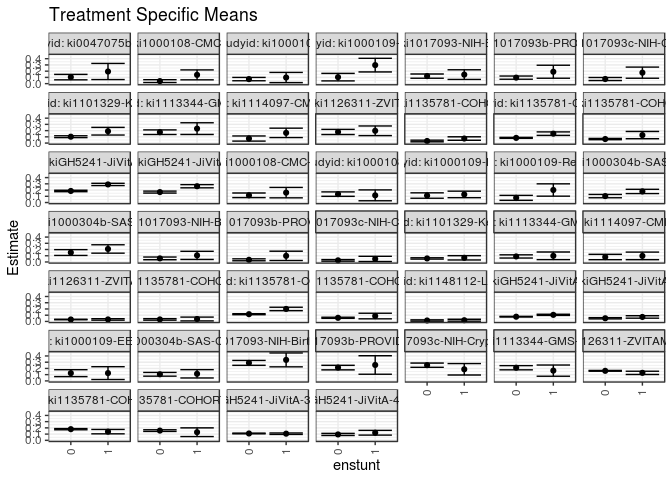

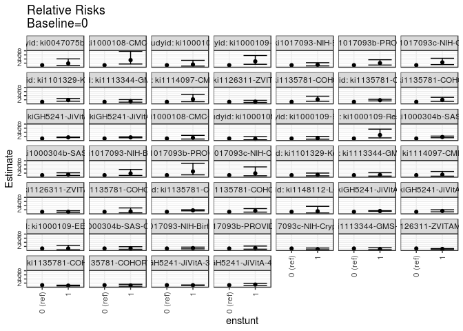

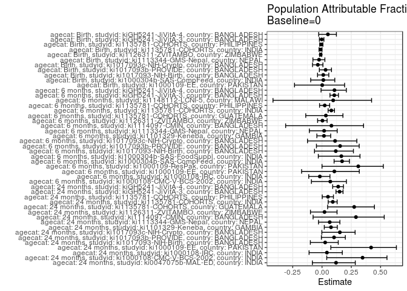

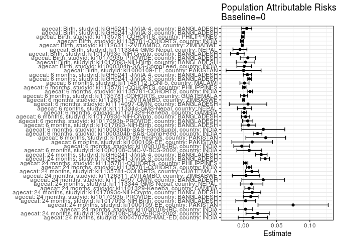

## Results Table

### Parameter: TSM

| agecat | studyid | country | intervention_level | baseline_level | estimate | ci_lower | ci_upper |
| --- | --- | --- | --- | --- | --- | --- | --- |
| Birth | ki1000109-EE | PAKISTAN | 0 | NA | 0.1240876 | 0.0687255 | 0.1794497 |
| Birth | ki1000109-EE | PAKISTAN | 1 | NA | 0.1250000 | 0.0222203 | 0.2277797 |
| Birth | ki1000304b-SAS-CompFeed | INDIA | 0 | NA | 0.1057483 | 0.0756339 | 0.1358626 |
| Birth | ki1000304b-SAS-CompFeed | INDIA | 1 | NA | 0.1136796 | 0.0468465 | 0.1805126 |
| Birth | ki1017093-NIH-Birth | BANGLADESH | 0 | NA | 0.2889606 | 0.2494470 | 0.3284743 |
| Birth | ki1017093-NIH-Birth | BANGLADESH | 1 | NA | 0.3370829 | 0.2256622 | 0.4485037 |
| Birth | ki1017093b-PROVIDE | BANGLADESH | 0 | NA | 0.2132372 | 0.1769359 | 0.2495385 |
| Birth | ki1017093b-PROVIDE | BANGLADESH | 1 | NA | 0.2553462 | 0.1068993 | 0.4037931 |
| Birth | ki1017093c-NIH-Crypto | BANGLADESH | 0 | NA | 0.2519477 | 0.2177838 | 0.2861115 |
| Birth | ki1017093c-NIH-Crypto | BANGLADESH | 1 | NA | 0.1862708 | 0.0944031 | 0.2781385 |
| Birth | ki1113344-GMS-Nepal | NEPAL | 0 | NA | 0.2111546 | 0.1776502 | 0.2446590 |
| Birth | ki1113344-GMS-Nepal | NEPAL | 1 | NA | 0.1646957 | 0.0747171 | 0.2546744 |
| Birth | ki1126311-ZVITAMBO | ZIMBABWE | 0 | NA | 0.1613376 | 0.1548152 | 0.1678599 |
| Birth | ki1126311-ZVITAMBO | ZIMBABWE | 1 | NA | 0.1291122 | 0.1030096 | 0.1552149 |
| Birth | ki1135781-COHORTS | INDIA | 0 | NA | 0.1792151 | 0.1693537 | 0.1890764 |
| Birth | ki1135781-COHORTS | INDIA | 1 | NA | 0.1394328 | 0.1041360 | 0.1747295 |
| Birth | ki1135781-COHORTS | PHILIPPINES | 0 | NA | 0.1565045 | 0.1430770 | 0.1699319 |
| Birth | ki1135781-COHORTS | PHILIPPINES | 1 | NA | 0.1303249 | 0.0604108 | 0.2002389 |
| Birth | kiGH5241-JiVitA-3 | BANGLADESH | 0 | NA | 0.1098322 | 0.1042377 | 0.1154266 |
| Birth | kiGH5241-JiVitA-3 | BANGLADESH | 1 | NA | 0.1069199 | 0.0953797 | 0.1184601 |
| Birth | kiGH5241-JiVitA-4 | BANGLADESH | 0 | NA | 0.0947459 | 0.0782909 | 0.1112009 |
| Birth | kiGH5241-JiVitA-4 | BANGLADESH | 1 | NA | 0.1218549 | 0.0838813 | 0.1598286 |
| 6 months | ki1000108-CMC-V-BCS-2002 | INDIA | 0 | NA | 0.1161482 | 0.0792802 | 0.1530162 |
| 6 months | ki1000108-CMC-V-BCS-2002 | INDIA | 1 | NA | 0.1586997 | 0.0751786 | 0.2422208 |
| 6 months | ki1000108-IRC | INDIA | 0 | NA | 0.1348315 | 0.0993091 | 0.1703538 |
| 6 months | ki1000108-IRC | INDIA | 1 | NA | 0.1153846 | 0.0284424 | 0.2023268 |
| 6 months | ki1000109-EE | PAKISTAN | 0 | NA | 0.1121399 | 0.0686555 | 0.1556243 |
| 6 months | ki1000109-EE | PAKISTAN | 1 | NA | 0.1297373 | 0.0774702 | 0.1820045 |
| 6 months | ki1000109-ResPak | PAKISTAN | 0 | NA | 0.0751026 | 0.0353099 | 0.1148953 |
| 6 months | ki1000109-ResPak | PAKISTAN | 1 | NA | 0.2013959 | 0.1024075 | 0.3003843 |

[output cut: 62 more lines]

### Parameter: E(Y)

| agecat | studyid | country | intervention_level | baseline_level | estimate | ci_lower | ci_upper |
| --- | --- | --- | --- | --- | --- | --- | --- |
| Birth | ki1000109-EE | PAKISTAN | NA | NA | 0.1242938 | 0.0755526 | 0.1730349 |
| Birth | ki1000304b-SAS-CompFeed | INDIA | NA | NA | 0.1069810 | 0.0760961 | 0.1378659 |
| Birth | ki1017093-NIH-Birth | BANGLADESH | NA | NA | 0.2921739 | 0.2549711 | 0.3293768 |
| Birth | ki1017093b-PROVIDE | BANGLADESH | NA | NA | 0.2199248 | 0.1846953 | 0.2551543 |
| Birth | ki1017093c-NIH-Crypto | BANGLADESH | NA | NA | 0.2432815 | 0.2116319 | 0.2749310 |
| Birth | ki1113344-GMS-Nepal | NEPAL | NA | NA | 0.2059282 | 0.1745993 | 0.2372572 |
| Birth | ki1126311-ZVITAMBO | ZIMBABWE | NA | NA | 0.1595572 | 0.1532418 | 0.1658725 |
| Birth | ki1135781-COHORTS | INDIA | NA | NA | 0.1769740 | 0.1674681 | 0.1864799 |
| Birth | ki1135781-COHORTS | PHILIPPINES | NA | NA | 0.1555709 | 0.1423748 | 0.1687670 |
| Birth | kiGH5241-JiVitA-3 | BANGLADESH | NA | NA | 0.1095259 | 0.1044047 | 0.1146471 |
| Birth | kiGH5241-JiVitA-4 | BANGLADESH | NA | NA | 0.0997496 | 0.0843744 | 0.1151247 |
| 6 months | ki1000108-CMC-V-BCS-2002 | INDIA | NA | NA | 0.1250000 | 0.0911644 | 0.1588356 |
| 6 months | ki1000108-IRC | INDIA | NA | NA | 0.1323529 | 0.0994307 | 0.1652752 |
| 6 months | ki1000109-EE | PAKISTAN | NA | NA | 0.1253333 | 0.0917776 | 0.1588891 |
| 6 months | ki1000109-ResPak | PAKISTAN | NA | NA | 0.1087866 | 0.0692283 | 0.1483450 |
| 6 months | ki1000304b-SAS-CompFeed | INDIA | NA | NA | 0.1244378 | 0.0992652 | 0.1496104 |
| 6 months | ki1000304b-SAS-FoodSuppl | INDIA | NA | NA | 0.1815789 | 0.1427684 | 0.2203895 |
| 6 months | ki1017093-NIH-Birth | BANGLADESH | NA | NA | 0.0651769 | 0.0442802 | 0.0860736 |
| 6 months | ki1017093b-PROVIDE | BANGLADESH | NA | NA | 0.0414594 | 0.0255348 | 0.0573839 |
| 6 months | ki1017093c-NIH-Crypto | BANGLADESH | NA | NA | 0.0293706 | 0.0169860 | 0.0417552 |
| 6 months | ki1101329-Keneba | GAMBIA | NA | NA | 0.0579225 | 0.0479029 | 0.0679420 |
| 6 months | ki1113344-GMS-Nepal | NEPAL | NA | NA | 0.0904255 | 0.0667359 | 0.1141152 |
| 6 months | ki1114097-CMIN | BANGLADESH | NA | NA | 0.0864198 | 0.0510184 | 0.1218211 |
| 6 months | ki1126311-ZVITAMBO | ZIMBABWE | NA | NA | 0.0311581 | 0.0274654 | 0.0348509 |
| 6 months | ki1135781-COHORTS | GUATEMALA | NA | NA | 0.0332295 | 0.0219033 | 0.0445557 |
| 6 months | ki1135781-COHORTS | INDIA | NA | NA | 0.1262774 | 0.1184108 | 0.1341439 |
| 6 months | ki1135781-COHORTS | PHILIPPINES | NA | NA | 0.0594974 | 0.0505830 | 0.0684118 |
| 6 months | ki1148112-LCNI-5 | MALAWI | NA | NA | 0.0166865 | 0.0080138 | 0.0253592 |
| 6 months | kiGH5241-JiVitA-3 | BANGLADESH | NA | NA | 0.0846640 | 0.0798626 | 0.0894653 |
| 6 months | kiGH5241-JiVitA-4 | BANGLADESH | NA | NA | 0.0569005 | 0.0480577 | 0.0657432 |
| 24 months | ki0047075b-MAL-ED | INDIA | NA | NA | 0.1189427 | 0.0767376 | 0.1611478 |
| 24 months | ki1000108-CMC-V-BCS-2002 | INDIA | NA | NA | 0.0618280 | 0.0373207 | 0.0863352 |
| 24 months | ki1000108-IRC | INDIA | NA | NA | 0.0757946 | 0.0501131 | 0.1014762 |
| 24 months | ki1000109-EE | PAKISTAN | NA | NA | 0.1785714 | 0.1204842 | 0.2366587 |
| 24 months | ki1017093-NIH-Birth | BANGLADESH | NA | NA | 0.1238318 | 0.0925894 | 0.1550741 |
| 24 months | ki1017093b-PROVIDE | BANGLADESH | NA | NA | 0.1070812 | 0.0818727 | 0.1322897 |
| 24 months | ki1017093c-NIH-Crypto | BANGLADESH | NA | NA | 0.0875486 | 0.0630907 | 0.1120065 |
| 24 months | ki1101329-Keneba | GAMBIA | NA | NA | 0.1106605 | 0.0958563 | 0.1254646 |
| 24 months | ki1113344-GMS-Nepal | NEPAL | NA | NA | 0.1868583 | 0.1522030 | 0.2215136 |
| 24 months | ki1114097-CMIN | BANGLADESH | NA | NA | 0.1028807 | 0.0646041 | 0.1411572 |
| 24 months | ki1126311-ZVITAMBO | ZIMBABWE | NA | NA | 0.1824480 | 0.1460286 | 0.2188675 |
| 24 months | ki1135781-COHORTS | GUATEMALA | NA | NA | 0.0462107 | 0.0336957 | 0.0587258 |
| 24 months | ki1135781-COHORTS | INDIA | NA | NA | 0.0916651 | 0.0838893 | 0.0994409 |
| 24 months | ki1135781-COHORTS | PHILIPPINES | NA | NA | 0.0681911 | 0.0582056 | 0.0781766 |
| 24 months | kiGH5241-JiVitA-3 | BANGLADESH | NA | NA | 0.2182959 | 0.2084450 | 0.2281469 |
| 24 months | kiGH5241-JiVitA-4 | BANGLADESH | NA | NA | 0.1942978 | 0.1810880 | 0.2075076 |

### Parameter: RR

| agecat | studyid | country | intervention_level | baseline_level | estimate | ci_lower | ci_upper |
| --- | --- | --- | --- | --- | --- | --- | --- |
| Birth | ki1000109-EE | PAKISTAN | 0 | 0 | 1.0000000 | 1.0000000 | 1.0000000 |
| Birth | ki1000109-EE | PAKISTAN | 1 | 0 | 1.0073529 | 0.3952817 | 2.5671818 |
| Birth | ki1000304b-SAS-CompFeed | INDIA | 0 | 0 | 1.0000000 | 1.0000000 | 1.0000000 |
| Birth | ki1000304b-SAS-CompFeed | INDIA | 1 | 0 | 1.0750017 | 0.6197938 | 1.8645373 |
| Birth | ki1017093-NIH-Birth | BANGLADESH | 0 | 0 | 1.0000000 | 1.0000000 | 1.0000000 |
| Birth | ki1017093-NIH-Birth | BANGLADESH | 1 | 0 | 1.1665359 | 0.8157953 | 1.6680729 |
| Birth | ki1017093b-PROVIDE | BANGLADESH | 0 | 0 | 1.0000000 | 1.0000000 | 1.0000000 |
| Birth | ki1017093b-PROVIDE | BANGLADESH | 1 | 0 | 1.1974750 | 0.6530437 | 2.1957892 |
| Birth | ki1017093c-NIH-Crypto | BANGLADESH | 0 | 0 | 1.0000000 | 1.0000000 | 1.0000000 |
| Birth | ki1017093c-NIH-Crypto | BANGLADESH | 1 | 0 | 0.7393235 | 0.4430956 | 1.2335921 |
| Birth | ki1113344-GMS-Nepal | NEPAL | 0 | 0 | 1.0000000 | 1.0000000 | 1.0000000 |
| Birth | ki1113344-GMS-Nepal | NEPAL | 1 | 0 | 0.7799770 | 0.4413897 | 1.3782927 |
| Birth | ki1126311-ZVITAMBO | ZIMBABWE | 0 | 0 | 1.0000000 | 1.0000000 | 1.0000000 |
| Birth | ki1126311-ZVITAMBO | ZIMBABWE | 1 | 0 | 0.8002614 | 0.6511897 | 0.9834589 |
| Birth | ki1135781-COHORTS | INDIA | 0 | 0 | 1.0000000 | 1.0000000 | 1.0000000 |
| Birth | ki1135781-COHORTS | INDIA | 1 | 0 | 0.7780191 | 0.6004788 | 1.0080519 |
| Birth | ki1135781-COHORTS | PHILIPPINES | 0 | 0 | 1.0000000 | 1.0000000 | 1.0000000 |
| Birth | ki1135781-COHORTS | PHILIPPINES | 1 | 0 | 0.8327231 | 0.4837830 | 1.4333446 |
| Birth | kiGH5241-JiVitA-3 | BANGLADESH | 0 | 0 | 1.0000000 | 1.0000000 | 1.0000000 |
| Birth | kiGH5241-JiVitA-3 | BANGLADESH | 1 | 0 | 0.9734844 | 0.8660858 | 1.0942010 |
| Birth | kiGH5241-JiVitA-4 | BANGLADESH | 0 | 0 | 1.0000000 | 1.0000000 | 1.0000000 |
| Birth | kiGH5241-JiVitA-4 | BANGLADESH | 1 | 0 | 1.2861234 | 0.9031062 | 1.8315823 |
| 6 months | ki1000108-CMC-V-BCS-2002 | INDIA | 0 | 0 | 1.0000000 | 1.0000000 | 1.0000000 |
| 6 months | ki1000108-CMC-V-BCS-2002 | INDIA | 1 | 0 | 1.3663545 | 0.7388233 | 2.5268892 |
| 6 months | ki1000108-IRC | INDIA | 0 | 0 | 1.0000000 | 1.0000000 | 1.0000000 |
| 6 months | ki1000108-IRC | INDIA | 1 | 0 | 0.8557692 | 0.3852033 | 1.9011805 |
| 6 months | ki1000109-EE | PAKISTAN | 0 | 0 | 1.0000000 | 1.0000000 | 1.0000000 |
| 6 months | ki1000109-EE | PAKISTAN | 1 | 0 | 1.1569239 | 0.6601463 | 2.0275398 |
| 6 months | ki1000109-ResPak | PAKISTAN | 0 | 0 | 1.0000000 | 1.0000000 | 1.0000000 |
| 6 months | ki1000109-ResPak | PAKISTAN | 1 | 0 | 2.6816107 | 1.2961862 | 5.5478416 |

[output cut: 62 more lines]

### Parameter: PAR

| agecat | studyid | country | intervention_level | baseline_level | estimate | ci_lower | ci_upper |
| --- | --- | --- | --- | --- | --- | --- | --- |
| Birth | ki1000109-EE | PAKISTAN | 0 | NA | 0.0002062 | -0.0261762 | 0.0265886 |
| Birth | ki1000304b-SAS-CompFeed | INDIA | 0 | NA | 0.0012327 | -0.0098363 | 0.0123017 |
| Birth | ki1017093-NIH-Birth | BANGLADESH | 0 | NA | 0.0032133 | -0.0108429 | 0.0172694 |
| Birth | ki1017093b-PROVIDE | BANGLADESH | 0 | NA | 0.0066876 | -0.0047277 | 0.0181029 |
| Birth | ki1017093c-NIH-Crypto | BANGLADESH | 0 | NA | -0.0086662 | -0.0195065 | 0.0021741 |
| Birth | ki1113344-GMS-Nepal | NEPAL | 0 | NA | -0.0052264 | -0.0157462 | 0.0052935 |
| Birth | ki1126311-ZVITAMBO | ZIMBABWE | 0 | NA | -0.0017804 | -0.0031515 | -0.0004093 |
| Birth | ki1135781-COHORTS | INDIA | 0 | NA | -0.0022411 | -0.0045060 | 0.0000238 |
| Birth | ki1135781-COHORTS | PHILIPPINES | 0 | NA | -0.0009336 | -0.0030538 | 0.0011866 |
| Birth | kiGH5241-JiVitA-3 | BANGLADESH | 0 | NA | -0.0003062 | -0.0024136 | 0.0018011 |
| Birth | kiGH5241-JiVitA-4 | BANGLADESH | 0 | NA | 0.0050037 | -0.0025712 | 0.0125785 |
| 6 months | ki1000108-CMC-V-BCS-2002 | INDIA | 0 | NA | 0.0088518 | -0.0098591 | 0.0275626 |
| 6 months | ki1000108-IRC | INDIA | 0 | NA | -0.0024785 | -0.0144652 | 0.0095081 |
| 6 months | ki1000109-EE | PAKISTAN | 0 | NA | 0.0131934 | -0.0173963 | 0.0437832 |
| 6 months | ki1000109-ResPak | PAKISTAN | 0 | NA | 0.0336840 | 0.0037350 | 0.0636330 |
| 6 months | ki1000304b-SAS-CompFeed | INDIA | 0 | NA | 0.0213052 | 0.0147094 | 0.0279011 |
| 6 months | ki1000304b-SAS-FoodSuppl | INDIA | 0 | NA | 0.0299695 | -0.0024017 | 0.0623408 |
| 6 months | ki1017093-NIH-Birth | BANGLADESH | 0 | NA | 0.0076548 | -0.0033541 | 0.0186637 |
| 6 months | ki1017093b-PROVIDE | BANGLADESH | 0 | NA | 0.0064040 | -0.0014720 | 0.0142800 |
| 6 months | ki1017093c-NIH-Crypto | BANGLADESH | 0 | NA | 0.0032695 | -0.0030052 | 0.0095442 |
| 6 months | ki1101329-Keneba | GAMBIA | 0 | NA | 0.0009680 | -0.0024539 | 0.0043899 |
| 6 months | ki1113344-GMS-Nepal | NEPAL | 0 | NA | 0.0016306 | -0.0091092 | 0.0123704 |
| 6 months | ki1114097-CMIN | BANGLADESH | 0 | NA | 0.0069496 | -0.0213264 | 0.0352255 |
| 6 months | ki1126311-ZVITAMBO | ZIMBABWE | 0 | NA | 0.0001163 | -0.0011472 | 0.0013799 |
| 6 months | ki1135781-COHORTS | GUATEMALA | 0 | NA | 0.0010910 | -0.0041736 | 0.0063557 |
| 6 months | ki1135781-COHORTS | INDIA | 0 | NA | 0.0100463 | 0.0065735 | 0.0135192 |
| 6 months | ki1135781-COHORTS | PHILIPPINES | 0 | NA | 0.0013797 | -0.0011950 | 0.0039544 |
| 6 months | ki1148112-LCNI-5 | MALAWI | 0 | NA | 0.0015922 | -0.0052488 | 0.0084332 |
| 6 months | kiGH5241-JiVitA-3 | BANGLADESH | 0 | NA | 0.0088730 | 0.0057660 | 0.0119800 |
| 6 months | kiGH5241-JiVitA-4 | BANGLADESH | 0 | NA | 0.0060379 | -0.0001949 | 0.0122706 |
| 24 months | ki0047075b-MAL-ED | INDIA | 0 | NA | 0.0142307 | -0.0078630 | 0.0363244 |
| 24 months | ki1000108-CMC-V-BCS-2002 | INDIA | 0 | NA | 0.0214066 | 0.0039067 | 0.0389065 |
| 24 months | ki1000108-IRC | INDIA | 0 | NA | 0.0031689 | -0.0075896 | 0.0139274 |
| 24 months | ki1000109-EE | PAKISTAN | 0 | NA | 0.0748291 | 0.0219611 | 0.1276972 |
| 24 months | ki1017093-NIH-Birth | BANGLADESH | 0 | NA | 0.0033138 | -0.0114178 | 0.0180454 |
| 24 months | ki1017093b-PROVIDE | BANGLADESH | 0 | NA | 0.0109931 | -0.0001652 | 0.0221514 |
| 24 months | ki1017093c-NIH-Crypto | BANGLADESH | 0 | NA | 0.0133359 | 0.0005021 | 0.0261697 |
| 24 months | ki1101329-Keneba | GAMBIA | 0 | NA | 0.0084855 | 0.0022461 | 0.0147248 |
| 24 months | ki1113344-GMS-Nepal | NEPAL | 0 | NA | 0.0122869 | -0.0048169 | 0.0293907 |
| 24 months | ki1114097-CMIN | BANGLADESH | 0 | NA | 0.0298046 | -0.0023367 | 0.0619459 |
| 24 months | ki1126311-ZVITAMBO | ZIMBABWE | 0 | NA | 0.0039089 | -0.0167583 | 0.0245762 |
| 24 months | ki1135781-COHORTS | GUATEMALA | 0 | NA | 0.0126935 | 0.0029966 | 0.0223903 |
| 24 months | ki1135781-COHORTS | INDIA | 0 | NA | 0.0084196 | 0.0048647 | 0.0119744 |
| 24 months | ki1135781-COHORTS | PHILIPPINES | 0 | NA | 0.0034677 | 0.0001757 | 0.0067598 |
| 24 months | kiGH5241-JiVitA-3 | BANGLADESH | 0 | NA | 0.0327017 | 0.0260916 | 0.0393117 |
| 24 months | kiGH5241-JiVitA-4 | BANGLADESH | 0 | NA | 0.0268591 | 0.0180801 | 0.0356380 |

### Parameter: PAF

| agecat | studyid | country | intervention_level | baseline_level | estimate | ci_lower | ci_upper |
| --- | --- | --- | --- | --- | --- | --- | --- |
| Birth | ki1000109-EE | PAKISTAN | 0 | NA | 0.0016589 | -0.2348505 | 0.1928700 |
| Birth | ki1000304b-SAS-CompFeed | INDIA | 0 | NA | 0.0115226 | -0.0966937 | 0.1090607 |
| Birth | ki1017093-NIH-Birth | BANGLADESH | 0 | NA | 0.0109979 | -0.0382931 | 0.0579489 |
| Birth | ki1017093b-PROVIDE | BANGLADESH | 0 | NA | 0.0304085 | -0.0228097 | 0.0808578 |
| Birth | ki1017093c-NIH-Crypto | BANGLADESH | 0 | NA | -0.0356221 | -0.0810665 | 0.0079119 |
| Birth | ki1113344-GMS-Nepal | NEPAL | 0 | NA | -0.0253795 | -0.0777249 | 0.0244234 |
| Birth | ki1126311-ZVITAMBO | ZIMBABWE | 0 | NA | -0.0111584 | -0.0197798 | -0.0026098 |
| Birth | ki1135781-COHORTS | INDIA | 0 | NA | -0.0126632 | -0.0255326 | 0.0000446 |
| Birth | ki1135781-COHORTS | PHILIPPINES | 0 | NA | -0.0060010 | -0.0197166 | 0.0075301 |
| Birth | kiGH5241-JiVitA-3 | BANGLADESH | 0 | NA | -0.0027961 | -0.0222192 | 0.0162579 |
| Birth | kiGH5241-JiVitA-4 | BANGLADESH | 0 | NA | 0.0501623 | -0.0284927 | 0.1228020 |
| 6 months | ki1000108-CMC-V-BCS-2002 | INDIA | 0 | NA | 0.0708141 | -0.0906303 | 0.2083602 |
| 6 months | ki1000108-IRC | INDIA | 0 | NA | -0.0187266 | -0.1133497 | 0.0678546 |
| 6 months | ki1000109-EE | PAKISTAN | 0 | NA | 0.1052667 | -0.1743900 | 0.3183289 |
| 6 months | ki1000109-ResPak | PAKISTAN | 0 | NA | 0.3096338 | -0.0001457 | 0.5234640 |
| 6 months | ki1000304b-SAS-CompFeed | INDIA | 0 | NA | 0.1712119 | 0.1030506 | 0.2341934 |
| 6 months | ki1000304b-SAS-FoodSuppl | INDIA | 0 | NA | 0.1650496 | -0.0318031 | 0.3243457 |
| 6 months | ki1017093-NIH-Birth | BANGLADESH | 0 | NA | 0.1174463 | -0.0642104 | 0.2680948 |
| 6 months | ki1017093b-PROVIDE | BANGLADESH | 0 | NA | 0.1544649 | -0.0475894 | 0.3175480 |
| 6 months | ki1017093c-NIH-Crypto | BANGLADESH | 0 | NA | 0.1113183 | -0.1239256 | 0.2973243 |
| 6 months | ki1101329-Keneba | GAMBIA | 0 | NA | 0.0167125 | -0.0441206 | 0.0740013 |
| 6 months | ki1113344-GMS-Nepal | NEPAL | 0 | NA | 0.0180326 | -0.1081330 | 0.1298337 |
| 6 months | ki1114097-CMIN | BANGLADESH | 0 | NA | 0.0804163 | -0.3105913 | 0.3547689 |
| 6 months | ki1126311-ZVITAMBO | ZIMBABWE | 0 | NA | 0.0037338 | -0.0376538 | 0.0434705 |
| 6 months | ki1135781-COHORTS | GUATEMALA | 0 | NA | 0.0328337 | -0.1388794 | 0.1786571 |
| 6 months | ki1135781-COHORTS | INDIA | 0 | NA | 0.0795578 | 0.0519838 | 0.1063297 |
| 6 months | ki1135781-COHORTS | PHILIPPINES | 0 | NA | 0.0231893 | -0.0209255 | 0.0653979 |
| 6 months | ki1148112-LCNI-5 | MALAWI | 0 | NA | 0.0954178 | -0.4186525 | 0.4232069 |
| 6 months | kiGH5241-JiVitA-3 | BANGLADESH | 0 | NA | 0.1048029 | 0.0678391 | 0.1403010 |
| 6 months | kiGH5241-JiVitA-4 | BANGLADESH | 0 | NA | 0.1061130 | -0.0084823 | 0.2076868 |
| 24 months | ki0047075b-MAL-ED | INDIA | 0 | NA | 0.1196432 | -0.0825540 | 0.2840744 |
| 24 months | ki1000108-CMC-V-BCS-2002 | INDIA | 0 | NA | 0.3462292 | 0.0402841 | 0.5546429 |
| 24 months | ki1000108-IRC | INDIA | 0 | NA | 0.0418093 | -0.1104940 | 0.1732244 |
| 24 months | ki1000109-EE | PAKISTAN | 0 | NA | 0.4190432 | 0.0750708 | 0.6350955 |
| 24 months | ki1017093-NIH-Birth | BANGLADESH | 0 | NA | 0.0267605 | -0.0996222 | 0.1386176 |
| 24 months | ki1017093b-PROVIDE | BANGLADESH | 0 | NA | 0.1026613 | -0.0054378 | 0.1991383 |
| 24 months | ki1017093c-NIH-Crypto | BANGLADESH | 0 | NA | 0.1523260 | -0.0015931 | 0.2825917 |
| 24 months | ki1101329-Keneba | GAMBIA | 0 | NA | 0.0766803 | 0.0193281 | 0.1306785 |
| 24 months | ki1113344-GMS-Nepal | NEPAL | 0 | NA | 0.0657552 | -0.0299704 | 0.1525841 |
| 24 months | ki1114097-CMIN | BANGLADESH | 0 | NA | 0.2897005 | -0.0762373 | 0.5312136 |
| 24 months | ki1126311-ZVITAMBO | ZIMBABWE | 0 | NA | 0.0214250 | -0.0986169 | 0.1283503 |
| 24 months | ki1135781-COHORTS | GUATEMALA | 0 | NA | 0.2746863 | 0.0477993 | 0.4475115 |
| 24 months | ki1135781-COHORTS | INDIA | 0 | NA | 0.0918512 | 0.0529194 | 0.1291826 |
| 24 months | ki1135781-COHORTS | PHILIPPINES | 0 | NA | 0.0508533 | 0.0018382 | 0.0974616 |
| 24 months | kiGH5241-JiVitA-3 | BANGLADESH | 0 | NA | 0.1498044 | 0.1190780 | 0.1794590 |
| 24 months | kiGH5241-JiVitA-4 | BANGLADESH | 0 | NA | 0.1382366 | 0.0911017 | 0.1829271 |